# Prompt Engineering Analysis with Anthropic's Claude

This notebook analyzes how different prompt engineering techniques affect Claude's output distributions, response characteristics, and behavior.

## Topics Covered:

1. Setting up the Anthropic API
2. Comparing different prompt engineering techniques
3. Analyzing temperature effects on output distribution
4. Visualizing output diversity and characteristics
5. Statistical analysis of prompt effectiveness

## Setup

```python
with open(".key", 'r') as fp:
    API_KEY = fp.read()
MODEL_NAME = "claude-3-haiku-20240307"

# Stores the API_KEY & MODEL_NAME variables for use across notebooks within the IPython store
%store API_KEY
%store MODEL_NAME
```

```
Stored 'API_KEY' (str)
Stored 'MODEL_NAME' (str)
```

```python
import anthropic
import os
import json
import numpy as np
import pandas as pd
import matplotlib.pyplot as plt
import seaborn as sns
from typing import List, Dict, Any
from collections import Counter
import time

# Set style for better visualizations
sns.set_style("whitegrid")
plt.rcParams['figure.figsize'] = (12, 8)

# Import our analyzer
from prompt_engineering_analyzer import PromptEngineeringAnalyzer

print("Setup complete!")
```

```
Setup complete!
```

## Configure API Key

Make sure you have your Anthropic API key set as an environment variable:

```
export ANTHROPIC_API_KEY='your-api-key-here'
```

Or set it directly in this notebook (not recommended for production):

```python
# Option 1: Use environment variable (recommended)
# Option 2: Set directly (uncomment and use with caution)
api_key = API_KEY

if not API_KEY:
    print("⚠️ WARNING: ANTHROPIC_API_KEY not found!")
    print("Please set your API key before proceeding.")
else:
    print("✓ API key configured")
```

```
✓ API key configured
```

## Initialize Analyzer

```python
# Initialize the analyzer with your preferred model
analyzer = PromptEngineeringAnalyzer(
    api_key=api_key,
    model=MODEL_NAME # or "claude-3-opus-20240229", etc.
)

print(f"Analyzer initialized with model: {analyzer.model}")
```

```
Analyzer initialized with model: claude-3-haiku-20240307
```

## 1. Basic Prompt Testing

Let's start with a simple example to see how Claude responds to a basic prompt.

```python
# Test a simple prompt
test_prompt = "Explain what a neural network is in one sentence."

response = analyzer.get_response(test_prompt, temperature=0.7)

print("Prompt:", test_prompt)
print("\nResponse:", response['response_text'])
print("\nMetadata:")
print(f"  - Input tokens: {response['input_tokens']}")
print(f"  - Output tokens: {response['output_tokens']}")
#print(f"  - Response length: {response['response_length']} characters")
print(f"  - Stop reason: {response['stop_reason']}")
```

```
Prompt: Explain what a neural network is in one sentence.

Response: A neural network is a machine learning model inspired by the structure and function of the human brain, designed to recognize patterns and make predictions from data.

Metadata:
  - Input tokens: 18
  - Output tokens: 32
  - Stop reason: end_turn
```

## 2. Comparing Prompt Engineering Techniques

Now let's compare different prompt engineering approaches on the same question.

```python
# Define your question
base_question = "What are the three most important factors in training a deep learning model?"

# Define different prompt engineering variants
prompt_variants = {
    "baseline": {
        "prompt": base_question,
        "system": ""
    },

    "with_system_prompt": {
        "prompt": base_question,
        "system": "You are an expert deep learning researcher with 10 years of experience."
    },

    "chain_of_thought": {
        "prompt": f"{base_question}\n\nLet's think through this step by step:",
        "system": ""
    },

    "structured": {
        "prompt": f"{base_question}\n\nProvide your answer in this format:\n1. [Factor]: [Explanation]\n2. [Factor]: [Explanation]\n3. [Factor]: [Explanation]",
        "system": ""
    },

    "few_shot": {
        "prompt": f"""Here's an example of explaining key factors:

Q: What are the three most important factors in building a web application?
A: The three most important factors are:
1. Security - Protecting user data and preventing vulnerabilities
2. Performance - Ensuring fast load times and responsive interactions
3. User Experience - Creating an intuitive and accessible interface

Q: {base_question}
A:""",
        "system": ""
    },

    "role_playing": {
        "prompt": base_question,
        "system": "You are Yann LeCun, discussing deep learning with a colleague. Be concise but insightful."
    }
}

print("Prompt variants defined:")
for name in prompt_variants.keys():
    print(f"  - {name}")
```

```
Prompt variants defined:
  - baseline
  - with_system_prompt
  - chain_of_thought
  - structured
  - few_shot
  - role_playing
```

### Run the comparison (this will take a few minutes)

```python
# Compare all variants
print("Running comparison... This may take a few minutes.\n")

df_variants = analyzer.compare_prompts(
    base_question=base_question,
    prompt_variants=prompt_variants,
    temperature=0.7,
    num_samples=5  # 5 samples per variant
)

print("\n✓ Comparison complete!")
print(f"\nTotal responses collected: {len(df_variants)}")
```

```
Running comparison... This may take a few minutes.

Testing variant: baseline
Testing variant: with_system_prompt
Testing variant: chain_of_thought
Testing variant: structured
Testing variant: few_shot
Testing variant: role_playing

✓ Comparison complete!

Total responses collected: 30
```

### View sample responses

```python
# Display one sample from each variant
for variant in df_variants['variant'].unique():
    sample = df_variants[df_variants['variant'] == variant].iloc[0]
    print("="*80)
    print(f"Variant: {variant}")
    print("="*80)
    print(f"Response:\n{sample['response_text']}")
    print(f"\nTokens: {sample['output_tokens']} | Length: {sample['response_length']} chars\n")
```

```
================================================================================
Variant: baseline
================================================================================
Response:
The three most important factors in training a deep learning model are:

1. Data Quality and Quantity:
   - The quality and quantity of the training data are crucial for the model's performance. The data should be representative, clean, and diverse to ensure the model learns the underlying patterns effectively.

2. Model Architecture:
   - The choice of the deep learning model architecture is critical. Different model architectures, such as convolutional neural networks (CNNs), recurrent neural networks (RNNs), or transformers, are suitable for different types of tasks and data. Selecting the appropriate architecture is essential…

3. Hyperparameter Tuning:
   - Hyperparameters are the settings of the deep learning model that are not learned from the data during the training process. Examples include learning rate, batch size, number of layers, regularization parameters, and optimization algorithms. Careful tuning of these hyperparameters can significa…

These three factors are interdependent and play a crucial role in the success of a deep learning model. Ensuring high-quality and sufficient training data, choosing the right model architecture, and optimizing the hyperparameters are essential steps in the deep learning model development process.

Tokens: 275 | Length: 1362 chars

================================================================================
Variant: with_system_prompt
================================================================================
Response:
As an expert deep learning researcher with 10 years of experience, I would say the three most important factors in training a deep learning model are:

1. Data Quality and Quantity:
   - The quality and quantity of the training data are crucial for the model's performance. High-quality, diverse, and representative data is essential for the model to learn meaningful patterns and generalize well.
   - Ensuring the training data is clean, labeled accurately, and covers the desired problem domain is a critical first step.
   - The amount of data available is also important, as deep learning models typically require large datasets to achieve good performance.

2. Model Architecture Design:
   - The choice of the neural network architecture is crucial for the model's performance. Different architectures are suitable for different types of problems, such as convolutional neural networks (CNNs) for image tasks, recurrent neural networks (RNNs) for sequential data, and transformers for la…
   - Designing an appropriate model architecture that can effectively capture the underlying patterns in the data is essential. This may involve selecting the right depth, width, and types of layers, as well as incorporating techniques like skip connections, attention mechanisms, and normalization l…

3. Hyperparameter Tuning:
   - Hyperparameters are the settings that are not learned during the training process but are set before the training begins. These include learning rate, batch size, optimizer, regularization methods, and others.
   - Tuning these hyperparameters can have a significant impact on the model's performance. Finding the optimal combination of hyperparameters through techniques like grid search, random search, or Bayesian optimization is crucial for achieving the best possible results.

In summary, the three most important factors in training a deep learning model are: (1) data quality and quantity, (2) model architecture design, and (3) hyperparameter tuning. These three elements work together to ensure the model can learn effectively and generalize well to new, unseen data.

```

[output cut: 62 more lines]

```
Tokens: 335 | Length: 1660 chars

================================================================================
Variant: role_playing
================================================================================
Response:
The three most important factors in training a deep learning model are:

1. Data Quality and Quantity: Having a large, diverse, and high-quality dataset is crucial for training deep learning models. The model's performance is heavily dependent on the data it is trained on.

2. Model Architecture: Designing an appropriate model architecture that can effectively capture the underlying patterns in the data is essential. The choice of model architecture can significantly impact the model's performance.

3. Hyperparameter Tuning: Carefully tuning the hyperparameters of the model, such as learning rate, batch size, and regularization, can greatly influence the model's convergence, generalization, and overall performance.

Tokens: 149 | Length: 724 chars
```

### Analyze output diversity

```python
diversity_metrics = analyzer.analyze_output_diversity(df_variants)

# Convert to DataFrame for better display
diversity_df = pd.DataFrame(diversity_metrics).T
diversity_df = diversity_df.round(3)

print("Output Diversity Metrics:\n")
print(diversity_df)

# Highlight key insights
print("\n" + "="*80)
print("KEY INSIGHTS:")
print("="*80)

most_diverse = diversity_df['uniqueness_ratio'].idxmax()
least_diverse = diversity_df['uniqueness_ratio'].idxmin()

print(f"\nMost diverse responses: {most_diverse} (ratio: {diversity_df.loc[most_diverse, 'uniqueness_ratio']:.3f})")
print(f"Least diverse responses: {least_diverse} (ratio: {diversity_df.loc[least_diverse, 'uniqueness_ratio']:.3f})")

longest = diversity_df['avg_response_length'].idxmax()
shortest = diversity_df['avg_response_length'].idxmin()

print(f"\nLongest responses: {longest} ({diversity_df.loc[longest, 'avg_response_length']:.0f} chars avg)")
print(f"Shortest responses: {shortest} ({diversity_df.loc[shortest, 'avg_response_length']:.0f} chars avg)")
```

```
Output Diversity Metrics:

                    unique_responses  total_samples  uniqueness_ratio  \
baseline                         5.0            5.0               1.0
with_system_prompt               5.0            5.0               1.0
chain_of_thought                 5.0            5.0               1.0
structured                       5.0            5.0               1.0
few_shot                         5.0            5.0               1.0
role_playing                     5.0            5.0               1.0

                    avg_response_length  avg_word_count  vocab_diversity  \
baseline                         1481.0           211.8            0.247
with_system_prompt               1787.2           258.2            0.273
chain_of_thought                 1794.4           271.6            0.242
structured                       1112.8           164.6            0.272
few_shot                         1520.8           219.6            0.259
role_playing                      866.0           126.8            0.311

                    total_vocabulary
baseline                       262.0
with_system_prompt             353.0
chain_of_thought               329.0
structured                     224.0
few_shot                       284.0
role_playing                   197.0

================================================================================
KEY INSIGHTS:
================================================================================

Most diverse responses: baseline (ratio: 1.000)
Least diverse responses: baseline (ratio: 1.000)

Longest responses: chain_of_thought (1794 chars avg)
Shortest responses: role_playing (866 chars avg)
```

### Visualize the comparison

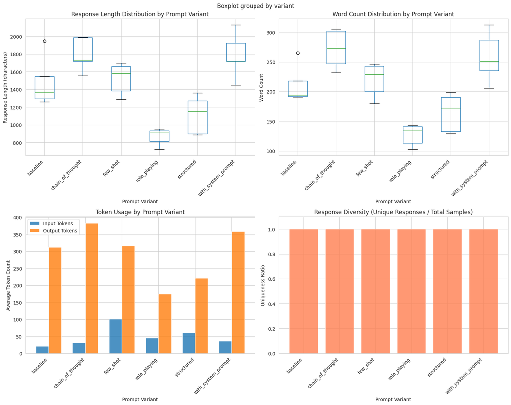

```python
analyzer.visualize_prompt_comparison(df_variants, save_path="prompt_comparison.png")
```

## 3. Temperature Analysis

Now let's see how temperature affects the output distribution for a single prompt.

```python
# Define a prompt for temperature analysis
temp_test_prompt = "Name three creative uses for artificial intelligence in healthcare."

print("Running temperature analysis...\n")
print(f"Prompt: {temp_test_prompt}")
print(f"Temperatures to test: [0.0, 0.3, 0.7, 1.0, 1.5]\n")

df_temperature = analyzer.analyze_temperature_effects(
    prompt=temp_test_prompt,
    system="You are a creative AI assistant.",
    temperatures=[0.0, 0.3, 0.7, 1.0],
    num_samples=10
)

print("\n✓ Temperature analysis complete!")
```

```
Running temperature analysis...

Prompt: Name three creative uses for artificial intelligence in healthcare.
Temperatures to test: [0.0, 0.3, 0.7, 1.0, 1.5]

Testing temperature: 0.0
Testing temperature: 0.3
Testing temperature: 0.7
Testing temperature: 1.0

✓ Temperature analysis complete!
```

### View responses at different temperatures

```python
# Show one example from each temperature
for temp in sorted(df_temperature['temperature'].unique()):
    sample = df_temperature[df_temperature['temperature'] == temp].iloc[0]
    print("="*80)
    print(f"Temperature: {temp}")
    print("="*80)
    print(sample['response_text'])
    print()
```

```
================================================================================
Temperature: 0.0
================================================================================
Here are three creative uses for artificial intelligence in healthcare:

1. AI-Powered Medical Imaging Analysis: AI algorithms can be trained to analyze medical images like X-rays, CT scans, and MRIs with superhuman accuracy. This can help doctors detect diseases and abnormalities earlier, leading to faster diagnoses and better patient outcomes.

2. Personalized Treatment Recommendations: AI systems can analyze a patient's medical history, genetics, and other data to recommend personalized treatment plans. This could lead to more effective, tailored therapies that take into account each individual's unique needs.

3. Virtual Nursing Assistants: AI-powered chatbots and virtual assistants can provide 24/7 support to patients, answering questions, monitoring symptoms, and even triaging minor issues. This could improve access to care, especially in underserved areas, and free up human healthcare providers to focu…

These are just a few examples of how AI can be creatively applied in the healthcare sector to improve patient outcomes, increase efficiency, and push the boundaries of modern medicine. The possibilities are truly exciting as this technology continues to advance.

================================================================================
Temperature: 0.3
================================================================================
Here are three creative uses for artificial intelligence in healthcare:

1. AI-Powered Medical Imaging Analysis: AI algorithms can be trained to analyze medical images like X-rays, CT scans, and MRIs with superhuman speed and accuracy. This can help doctors detect diseases and abnormalities earlier, leading to faster diagnoses and better patient outcomes.

2. Personalized Treatment Recommendations: AI systems can analyze a patient's medical history, genetic data, and other relevant information to recommend personalized treatment plans. This could lead to more effective, tailored therapies that take into account each individual's unique biology and nee…

3. Virtual Nursing Assistants: AI-powered chatbots and virtual assistants can be used to provide 24/7 support and guidance to patients. These virtual nurses can answer questions, provide wellness tips, monitor symptoms, and even escalate issues to human healthcare providers when necessary, improving…

These are just a few examples of how AI can be creatively applied in the healthcare sector to enhance medical capabilities, improve patient experiences, and ultimately save lives. The potential for AI in healthcare is vast and continues to grow as the technology advances.

================================================================================
Temperature: 0.7
================================================================================
Here are three creative uses for artificial intelligence in healthcare:

1. AI-Powered Personalized Treatment Plans: AI algorithms can analyze vast amounts of patient data, including medical history, genetic information, and real-time health monitoring, to develop personalized treatment plans tailored to an individual's unique needs. This could help healthcare providers …

2. AI-Assisted Diagnostic Tools: AI-powered diagnostic tools can analyze medical images, such as X-rays, CT scans, and MRI scans, to detect and identify potential health issues with greater accuracy and speed than human experts. This can help healthcare professionals make more informed and timely de…

3. AI-Driven Virtual Nursing Assistants: AI-powered virtual nursing assistants can provide 24/7 support and guidance to patients, answering their questions, monitoring their symptoms, and even providing emotional support. These virtual assistants can help reduce the workload on healthcare providers,…

These are just a few examples of how AI can be used creatively in healthcare to improve patient outcomes, enhance the efficiency of healthcare systems, and provide more personalized and accessible care.

================================================================================
Temperature: 1.0
================================================================================
Here are three creative uses for artificial intelligence in healthcare:

1. Predictive Analytics for Early Disease Detection: AI systems can analyze large datasets of patient health information, medical records, and diagnostic test results to identify patterns and risk factors that could signal the early onset of diseases. This could allow for earlier intervention and mo…

2. Personalized Treatment Recommendations: AI algorithms can sift through a patient's unique genetic profile, medical history, and real-time health data to recommend customized treatment plans and medication dosages. This personalized approach can improve outcomes and reduce trial-and-error in care.

3. Intelligent Chatbots for Patient Support: AI-powered chatbots and virtual assistants can provide 24/7 access to medical information, symptom checking, appointment scheduling, and even emotional support for patients. This can improve patient engagement and free up healthcare providers to focus on …

These are just a few examples of how artificial intelligence is being creatively applied in the healthcare industry to enhance diagnosis, treatment, and patient experience. The possibilities continue to expand as the technology advances.
```

### Temperature statistics

```python
# Calculate statistics by temperature
temp_stats = df_temperature.groupby('temperature').agg({
    'response_length': ['mean', 'std', 'min', 'max'],
    'word_count': ['mean', 'std'],
    'output_tokens': ['mean', 'std']
}).round(2)

print("Statistics by Temperature:\n")
print(temp_stats)

# Calculate uniqueness ratio by temperature
print("\n" + "="*80)
print("Response Uniqueness by Temperature:")
print("="*80)

for temp in sorted(df_temperature['temperature'].unique()):
    responses = df_temperature[df_temperature['temperature'] == temp]['response_text'].tolist()
    unique_ratio = len(set(responses)) / len(responses)
    print(f"Temperature {temp}: {unique_ratio:.2%} unique responses ({len(set(responses))}/{len(responses)})")
```

```
Statistics by Temperature:

            response_length                     word_count         \
                       mean     std   min   max       mean    std
temperature
0.0                  1204.4    2.95  1203  1210      173.2   0.42
0.3                  1141.0  111.93   875  1254      162.1  17.65
0.7                  1138.1  188.48   856  1457      159.1  27.04
1.0                  1199.9  180.63  1000  1531      167.5  26.55

            output_tokens
                     mean    std
temperature
0.0                 246.2   0.42
0.3                 232.6  18.51
0.7                 225.4  34.67
1.0                 235.7  30.85

================================================================================
Response Uniqueness by Temperature:
================================================================================
Temperature 0.0: 20.00% unique responses (2/10)
Temperature 0.3: 100.00% unique responses (10/10)
Temperature 0.7: 100.00% unique responses (10/10)
Temperature 1.0: 100.00% unique responses (10/10)
```

### Visualize temperature effects

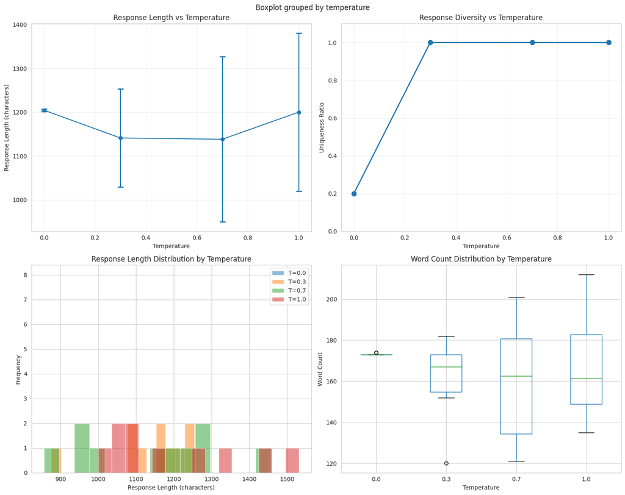

```python
analyzer.visualize_temperature_effects(df_temperature, save_path="temperature_effects.png")
```

## 4. Custom Analysis: Response Patterns

Let's do some custom analysis on common patterns in the responses.

```python
def analyze_response_patterns(df, text_column='response_text'):
    """
    Analyze common patterns in responses.
    """
    patterns = {
        'starts_with_number': 0,
        'contains_list': 0,
        'contains_bullet': 0,
        'starts_with_capital': 0,
        'contains_colon': 0,
    }

    for text in df[text_column]:
        if text[0].isdigit():
            patterns['starts_with_number'] += 1
        if any(text.startswith(f"{i}.") or f"\n{i}." in text for i in range(1, 10)):
            patterns['contains_list'] += 1
        if '•' in text or '- ' in text or '* ' in text:
            patterns['contains_bullet'] += 1
        if text[0].isupper():
            patterns['starts_with_capital'] += 1
        if ':' in text:
            patterns['contains_colon'] += 1

    # Convert to percentages
    total = len(df)
    for key in patterns:
        patterns[key] = (patterns[key] / total) * 100

    return patterns

# Analyze patterns by variant
print("Response Patterns by Variant:\n")
print("=" * 80)

for variant in df_variants['variant'].unique():
    variant_df = df_variants[df_variants['variant'] == variant]
    patterns = analyze_response_patterns(variant_df)

    print(f"\n{variant}:")
    for pattern, percentage in patterns.items():
        print(f"  {pattern}: {percentage:.1f}%")
```

```
Response Patterns by Variant:

================================================================================

baseline:
  starts_with_number: 0.0%
  contains_list: 100.0%
  contains_bullet: 100.0%
  starts_with_capital: 100.0%
  contains_colon: 100.0%

with_system_prompt:
  starts_with_number: 0.0%
  contains_list: 100.0%
  contains_bullet: 80.0%
  starts_with_capital: 100.0%
  contains_colon: 100.0%

chain_of_thought:
  starts_with_number: 0.0%
  contains_list: 100.0%
  contains_bullet: 100.0%
  starts_with_capital: 100.0%
  contains_colon: 100.0%

structured:
  starts_with_number: 60.0%
  contains_list: 100.0%
  contains_bullet: 0.0%
  starts_with_capital: 40.0%
  contains_colon: 100.0%

few_shot:
  starts_with_number: 0.0%
  contains_list: 100.0%
  contains_bullet: 100.0%
  starts_with_capital: 100.0%
  contains_colon: 100.0%

role_playing:
  starts_with_number: 0.0%
  contains_list: 100.0%
  contains_bullet: 40.0%
  starts_with_capital: 100.0%
  contains_colon: 100.0%
```

## 5. Word Frequency Analysis

Analyze which words appear most frequently in different prompt variants.

```python
from collections import Counter
import re

def get_top_words(df, variant, n=20, min_length=4):
    """
    Get top N words for a specific variant.
    """
    # Get all responses for this variant
    texts = df[df['variant'] == variant]['response_text'].tolist()

    # Combine all text
    combined_text = ' '.join(texts).lower()

    # Extract words (alphanumeric only)
    words = re.findall(r'\b[a-z]+\b', combined_text)

    # Filter by length and remove common stop words
    stop_words = {'the', 'this', 'that', 'with', 'from', 'have', 'they', 'will', 'your',
                  'more', 'about', 'which', 'their', 'there', 'than', 'them', 'these',
                  'been', 'were', 'when', 'where', 'also', 'can', 'are', 'and', 'for'}

    words = [w for w in words if len(w) >= min_length and w not in stop_words]

    # Count and return top N
    return Counter(words).most_common(n)

# Analyze top words for each variant
print("Top 15 Words by Variant:\n")
print("=" * 80)

for variant in df_variants['variant'].unique():
    print(f"\n{variant}:")
    top_words = get_top_words(df_variants, variant, n=15)

    for word, count in top_words:
        print(f"  {word}: {count}")
```

```
Top 15 Words by Variant:

================================================================================

baseline:
  model: 50
  data: 30
  learning: 27
  training: 20
  deep: 17
  performance: 17
  architecture: 16
  quality: 15
  factors: 14
  tuning: 13
  quantity: 12
  three: 11
  crucial: 10
  hyperparameters: 10
  such: 9

with_system_prompt:
  model: 56
  data: 32
  learning: 30
  training: 29
  deep: 23
  performance: 18
  architecture: 17
  quality: 16
  factors: 13
  three: 12
  quantity: 12
  crucial: 10
  techniques: 10
  tuning: 10
  hyperparameters: 9

chain_of_thought:
  model: 62
```

[output cut: 50 more lines]

```
  model: 30
  learning: 18
  training: 13
  data: 13
  deep: 12
  architecture: 12
  quality: 11
  optimization: 9
  three: 8
  factors: 8
  performance: 8
  quantity: 6
  dataset: 6
  models: 6
  patterns: 6
```

## 6. Visualize Word Frequency Comparison

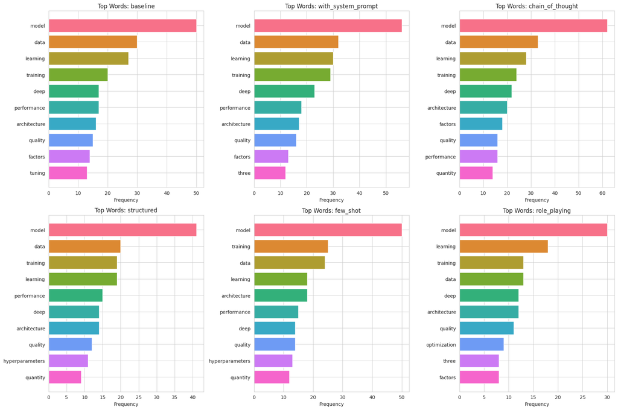

```python
# Create a comparison of top words across variants
fig, axes = plt.subplots(2, 3, figsize=(18, 12))
axes = axes.flatten()

for idx, variant in enumerate(df_variants['variant'].unique()):
    if idx >= len(axes):
        break

    top_words = get_top_words(df_variants, variant, n=10)
    words, counts = zip(*top_words)

    axes[idx].barh(words, counts, color=sns.color_palette("husl", 10))
    axes[idx].set_xlabel('Frequency')
    axes[idx].set_title(f'Top Words: {variant}')
    axes[idx].invert_yaxis()

# Hide any unused subplots
for idx in range(len(df_variants['variant'].unique()), len(axes)):
    axes[idx].axis('off')

plt.tight_layout()
plt.savefig('word_frequency_comparison.png', dpi=300, bbox_inches='tight')
plt.show()
```

## 7. Save Results

```python
# Save all results
analyzer.save_results(df_variants, "prompt_variants_results")
analyzer.save_results(df_temperature, "temperature_analysis_results")

print("Results saved!")
print("\nGenerated files:")
print("  - prompt_variants_results.csv")
print("  - prompt_variants_results.json")
print("  - temperature_analysis_results.csv")
print("  - temperature_analysis_results.json")
print("  - prompt_comparison.png")
print("  - temperature_effects.png")
print("  - word_frequency_comparison.png")
```

```
Results saved to prompt_variants_results.csv and prompt_variants_results.json
Results saved to temperature_analysis_results.csv and temperature_analysis_results.json
Results saved!

Generated files:
  - prompt_variants_results.csv
  - prompt_variants_results.json
  - temperature_analysis_results.csv
  - temperature_analysis_results.json
  - prompt_comparison.png
  - temperature_effects.png
  - word_frequency_comparison.png
```

## 8. One-Shot vs Multi-Shot Prompting Analysis

This section analyzes how the number of examples (zero-shot, one-shot, few-shot, multi-shot) affects:

1. **Response Consistency (Stationarity)**: How stable and predictable are the outputs?
2. **Format Adherence**: Does the model follow the format shown in examples?
3. **Response Quality**: How well does it extract structured information?

We'll test this with a product review classification task, extracting sentiment and key features.

```python
# Define the task: Extract sentiment and key features from a product review
test_review = """I recently purchased the UltraBook Pro laptop and I'm thoroughly impressed.
The battery life easily lasts 12 hours, the display is crystal clear, and the keyboard is comfortable
for long typing sessions. However, the price point is quite high and it gets warm during intensive tasks."""

# Define variants with different numbers of examples
shot_variants = {
    "zero_shot": {
        "prompt": f"""Analyze this product review and provide:
1. Overall sentiment (Positive/Negative/Mixed)
2. Key positive features (list)
3. Key negative features (list)

Review: {test_review}""",
        "system": ""
    },

    "one_shot": {
        "prompt": f"""Analyze product reviews and extract sentiment and key features.

Example:
Review: "The wireless headphones sound great and are very comfortable. Battery lasts 20 hours.
But they're expensive and don't fold for storage."

Analysis:
1. Overall sentiment: Mixed
2. Key positive features:
   - Great sound quality
   - Very comfortable
   - 20-hour battery life
3. Key negative features:
   - Expensive
   - Don't fold for storage

Now analyze this review:
Review: {test_review}

Analysis:""",
        "system": ""
    },

    "two_shot": {
        "prompt": f"""Analyze product reviews and extract sentiment and key features.

Example 1:
Review: "The wireless headphones sound great and are very comfortable. Battery lasts 20 hours.
But they're expensive and don't fold for storage."

Analysis:
1. Overall sentiment: Mixed
2. Key positive features:
   - Great sound quality
   - Very comfortable
   - 20-hour battery life
3. Key negative features:
   - Expensive
   - Don't fold for storage

Example 2:
Review: "This smartphone is amazing! Super fast processor, excellent camera, beautiful design.
Absolutely love it!"

Analysis:
1. Overall sentiment: Positive
2. Key positive features:
   - Super fast processor
   - Excellent camera
   - Beautiful design
3. Key negative features:
   - None mentioned

Now analyze this review:
Review: {test_review}

Analysis:""",
        "system": ""
    },

    "multi_shot": {
        "prompt": f"""Analyze product reviews and extract sentiment and key features.

Example 1:
Review: "The wireless headphones sound great and are very comfortable. Battery lasts 20 hours.
But they're expensive and don't fold for storage."

Analysis:
1. Overall sentiment: Mixed
2. Key positive features:
   - Great sound quality
   - Very comfortable
   - 20-hour battery life
3. Key negative features:
   - Expensive
   - Don't fold for storage

Example 2:
Review: "This smartphone is amazing! Super fast processor, excellent camera, beautiful design.
Absolutely love it!"

Analysis:
1. Overall sentiment: Positive
2. Key positive features:
   - Super fast processor
   - Excellent camera
   - Beautiful design
3. Key negative features:
   - None mentioned

Example 3:
Review: "Terrible coffee maker. Leaked water everywhere, broke after 2 weeks. Complete waste of money."

Analysis:
1. Overall sentiment: Negative
2. Key positive features:
   - None mentioned
3. Key negative features:
   - Leaks water
   - Poor durability (broke after 2 weeks)
   - Poor value for money

Example 4:
Review: "The fitness tracker works well for basic tracking. Steps and heart rate are accurate.
However, the app is clunky and syncing is unreliable."

Analysis:
1. Overall sentiment: Mixed
2. Key positive features:
   - Accurate step tracking
   - Accurate heart rate monitoring
3. Key negative features:
   - Clunky app interface
   - Unreliable syncing

Now analyze this review:
Review: {test_review}

Analysis:""",
        "system": ""
    }
}

print("Few-Shot Variants Defined:")
print(f"  - zero_shot: 0 examples")
print(f"  - one_shot: 1 example")
print(f"  - two_shot: 2 examples")
print(f"  - multi_shot: 4 examples")
print(f"\nTest review: {test_review[:100]}...")
```

```
Few-Shot Variants Defined:
  - zero_shot: 0 examples
  - one_shot: 1 example
  - two_shot: 2 examples
  - multi_shot: 4 examples

Test review: I recently purchased the UltraBook Pro laptop and I'm thoroughly impressed.
The battery life easily...
```

### Run the Few-Shot Experiment

We'll run each variant multiple times to measure consistency (stationarity) across responses.

```python
# Run the experiment - test each variant multiple times
print("Running few-shot analysis... This will take a few minutes.\n")

df_few_shot = analyzer.compare_prompts(
    base_question=test_review,
    prompt_variants=shot_variants,
    temperature=0.7,  # Using temperature 0.7 for some diversity
    num_samples=15  # More samples to better measure stationarity
)

print("\n✓ Few-shot analysis complete!")
print(f"\nTotal responses collected: {len(df_few_shot)}")
print(f"Variants tested: {df_few_shot['variant'].unique().tolist()}")
```

```
Running few-shot analysis... This will take a few minutes.

Testing variant: zero_shot
Testing variant: one_shot
Testing variant: two_shot
Testing variant: multi_shot

✓ Few-shot analysis complete!

Total responses collected: 60
Variants tested: ['zero_shot', 'one_shot', 'two_shot', 'multi_shot']
```

### Analyze Prompt Stationarity

**Stationarity** refers to how consistent and predictable the model's responses are. High stationarity means the model produces similar outputs given the same prompt (desirable for production use).

We'll measure:

1. **Response Variance**: Standard deviation in response length and word count
2. **Format Consistency**: How often responses follow the expected format
3. **Uniqueness Ratio**: Proportion of unique responses (lower = more stationary)
4. **Content Consistency**: Similarity in key terms used across responses

```python
def analyze_stationarity(df, text_column='response_text'):
    """
    Analyze prompt stationarity - how consistent are the responses?

    Returns metrics for each variant:
    - Response length variance (lower = more stationary)
    - Word count variance (lower = more stationary)
    - Uniqueness ratio (lower = more stationary)
    - Format consistency (higher = more stationary)
    - Coefficient of variation for length (normalized measure)
    """
    stationarity_metrics = {}

    for variant in df['variant'].unique():
        variant_df = df[df['variant'] == variant]
        responses = variant_df[text_column].tolist()

        # Basic stats
        lengths = variant_df['response_length'].values
        word_counts = variant_df['word_count'].values

        # Uniqueness
        unique_responses = len(set(responses))
        total_responses = len(responses)
        uniqueness_ratio = unique_responses / total_responses

        # Variance metrics
        length_std = np.std(lengths)
        length_mean = np.mean(lengths)
        word_count_std = np.std(word_counts)
        word_count_mean = np.mean(word_counts)

        # Coefficient of variation (CV) - normalized measure of dispersion
        # Lower CV = more stationary
        length_cv = (length_std / length_mean) if length_mean > 0 else 0
        word_count_cv = (word_count_std / word_count_mean) if word_count_mean > 0 else 0

        # Format consistency - check if responses follow numbered list format
        format_matches = 0
        for response in responses:
            # Check if response contains "1." and "2." and "3."
            if all(f"{i}." in response for i in [1, 2, 3]):
                format_matches += 1
        format_consistency = format_matches / total_responses

        # Content consistency - measure overlap in key terms
        # Extract key terms from all responses
        all_terms = []
        for response in responses:
            # Simple term extraction (lowercased words)
            terms = set(response.lower().split())
            all_terms.append(terms)

        # Calculate average Jaccard similarity between all pairs
        if len(all_terms) > 1:
            similarities = []
            for i in range(len(all_terms)):
                for j in range(i + 1, len(all_terms)):
                    intersection = len(all_terms[i] & all_terms[j])
                    union = len(all_terms[i] | all_terms[j])
                    similarity = intersection / union if union > 0 else 0
                    similarities.append(similarity)
            avg_content_similarity = np.mean(similarities) if similarities else 0
        else:
            avg_content_similarity = 1.0

        stationarity_metrics[variant] = {
            'uniqueness_ratio': uniqueness_ratio,
            'length_std': length_std,
            'length_cv': length_cv,
            'word_count_std': word_count_std,
            'word_count_cv': word_count_cv,
            'format_consistency': format_consistency,
            'content_similarity': avg_content_similarity,
            'num_samples': total_responses,
            # Lower stationarity_score = more stationary
            # Combine multiple metrics (normalized)
            'stationarity_score': (uniqueness_ratio + length_cv + word_count_cv) / 3 - (format_consistency + avg_content_similarity) / 2
        }

    return stationarity_metrics

# Analyze stationarity
print("Analyzing prompt stationarity...\n")
stationarity_metrics = analyze_stationarity(df_few_shot)

# Convert to DataFrame for better visualization
stationarity_df = pd.DataFrame(stationarity_metrics).T
stationarity_df = stationarity_df.round(4)

# Sort by number of examples (0, 1, 2, 4)
shot_order = ['zero_shot', 'one_shot', 'two_shot', 'multi_shot']
stationarity_df = stationarity_df.reindex(shot_order)

print("=" * 80)
print("STATIONARITY METRICS BY VARIANT")
print("=" * 80)
print("\nLower values indicate MORE stationary (more consistent) responses")
print("Higher values indicate LESS stationary (more diverse) responses\n")
print(stationarity_df)

# Highlight key findings
print("\n" + "=" * 80)
print("KEY FINDINGS:")
print("=" * 80)

most_stationary = stationarity_df['stationarity_score'].idxmin()
least_stationary = stationarity_df['stationarity_score'].idxmax()

print(f"\nMost Stationary (most consistent): {most_stationary}")
print(f"  - Stationarity Score: {stationarity_df.loc[most_stationary, 'stationarity_score']:.4f}")
print(f"  - Uniqueness Ratio: {stationarity_df.loc[most_stationary, 'uniqueness_ratio']:.2%}")
print(f"  - Format Consistency: {stationarity_df.loc[most_stationary, 'format_consistency']:.2%}")
print(f"  - Content Similarity: {stationarity_df.loc[most_stationary, 'content_similarity']:.2%}")

print(f"\nLeast Stationary (most diverse): {least_stationary}")
print(f"  - Stationarity Score: {stationarity_df.loc[least_stationary, 'stationarity_score']:.4f}")
print(f"  - Uniqueness Ratio: {stationarity_df.loc[least_stationary, 'uniqueness_ratio']:.2%}")
print(f"  - Format Consistency: {stationarity_df.loc[least_stationary, 'format_consistency']:.2%}")
print(f"  - Content Similarity: {stationarity_df.loc[least_stationary, 'content_similarity']:.2%}")
```

```
Analyzing prompt stationarity...

================================================================================
STATIONARITY METRICS BY VARIANT
================================================================================

Lower values indicate MORE stationary (more consistent) responses
Higher values indicate LESS stationary (more diverse) responses

            uniqueness_ratio  length_std  length_cv  word_count_std  \
zero_shot             0.7333     29.6733     0.1093          3.3993
one_shot              1.0000    162.0509     0.2676         24.6913
two_shot              1.0000    128.0573     0.2235         19.6170
multi_shot            1.0000    162.8745     0.2866         25.5439

            word_count_cv  format_consistency  content_similarity  \
zero_shot          0.0797                 1.0              0.8121
one_shot           0.2657                 1.0              0.5325
two_shot           0.2224                 1.0              0.6111
multi_shot         0.2881                 1.0              0.6104

            num_samples  stationarity_score
zero_shot          15.0             -0.5986
one_shot           15.0             -0.2551
two_shot           15.0             -0.3236
multi_shot         15.0             -0.2803

================================================================================
KEY FINDINGS:
================================================================================

Most Stationary (most consistent): zero_shot
  - Stationarity Score: -0.5986
  - Uniqueness Ratio: 73.33%
  - Format Consistency: 100.00%
  - Content Similarity: 81.21%

Least Stationary (most diverse): one_shot
  - Stationarity Score: -0.2551
  - Uniqueness Ratio: 100.00%
  - Format Consistency: 100.00%
  - Content Similarity: 53.25%
```

### Visualize Sample Responses

Let's look at a few sample responses from each variant to see the differences.

```python
# Display 2 sample responses from each variant
for variant in shot_order:
    variant_responses = df_few_shot[df_few_shot['variant'] == variant]['response_text'].tolist()[:2]

    print("=" * 80)
    print(f"VARIANT: {variant.upper()} ({variant.split('_')[0]} examples)")
    print("=" * 80)

    for idx, response in enumerate(variant_responses, 1):
        print(f"\nSample {idx}:")
        print("-" * 80)
        print(response)
        print()
```

```
================================================================================
VARIANT: ZERO_SHOT (zero examples)
================================================================================

Sample 1:
--------------------------------------------------------------------------------
Analyzing the product review:

1. Overall sentiment: Mixed

2. Key positive features:
   - Long battery life (12 hours)
   - Crystal clear display
   - Comfortable keyboard for long typing sessions

3. Key negative features:
   - High price point
   - Gets warm during intensive tasks


Sample 2:
--------------------------------------------------------------------------------
Analyzing the provided product review:

1. Overall sentiment: Mixed

2. Key positive features:
   - Long battery life (up to 12 hours)
   - Clear and high-quality display
   - Comfortable keyboard for extended use

3. Key negative features:
   - High price point
   - Gets warm during intensive tasks

================================================================================
VARIANT: ONE_SHOT (one examples)
================================================================================

Sample 1:
```

[output cut: 92 more lines]

```
--------------------------------------------------------------------------------
Analyzing the given review:

1. Overall sentiment: Mixed

2. Key positive features:
   - Long battery life (12 hours)
   - Crystal clear display
   - Comfortable keyboard for typing

3. Key negative features:
   - High price point
   - Gets warm during intensive tasks

In summary, the review presents a mixed sentiment towards the UltraBook Pro laptop. The key positive aspects highlighted are the long battery life, clear display, and comfortable keyboard. However, the reviewer also notes the high price point and the tendency of the laptop to get warm during intensi…
```

### Visualize Stationarity Metrics

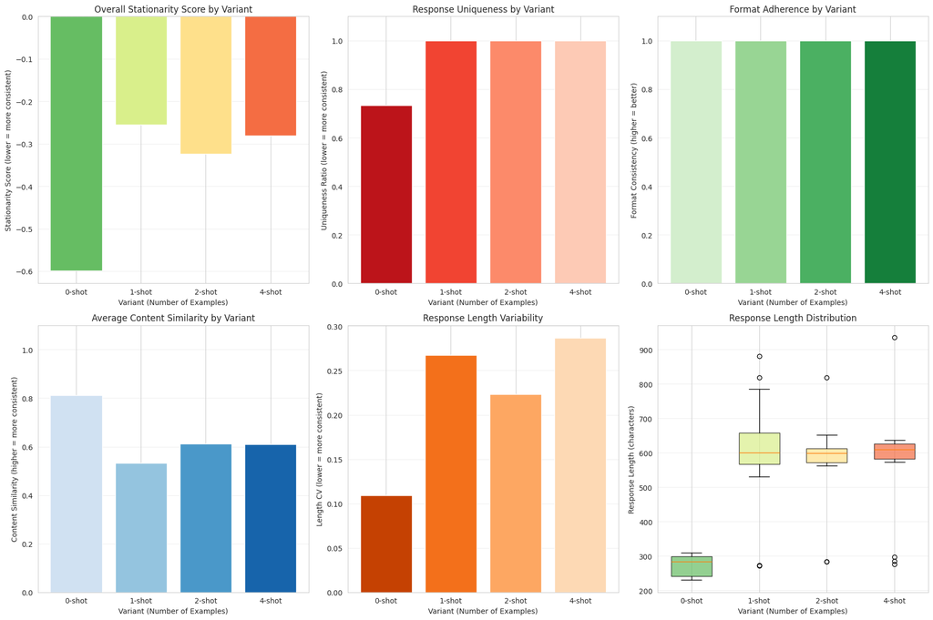

```
Visualization saved as 'few_shot_stationarity_analysis.png'
```

```python
# Create comprehensive visualizations for stationarity analysis
fig, axes = plt.subplots(2, 3, figsize=(18, 12))

# 1. Stationarity Score (lower = more stationary)
ax = axes[0, 0]
colors = sns.color_palette("RdYlGn_r", len(shot_order))
bars = ax.bar(shot_order, stationarity_df['stationarity_score'], color=colors)
ax.set_xlabel('Variant (Number of Examples)')
ax.set_ylabel('Stationarity Score (lower = more consistent)')
ax.set_title('Overall Stationarity Score by Variant')
ax.set_xticklabels(['0-shot', '1-shot', '2-shot', '4-shot'])
ax.axhline(y=0, color='black', linestyle='--', alpha=0.3)
ax.grid(axis='y', alpha=0.3)

# 2. Uniqueness Ratio (lower = more stationary)
ax = axes[0, 1]
bars = ax.bar(shot_order, stationarity_df['uniqueness_ratio'], color=sns.color_palette("Reds_r", len(shot_order)))
ax.set_xlabel('Variant (Number of Examples)')
ax.set_ylabel('Uniqueness Ratio (lower = more consistent)')
ax.set_title('Response Uniqueness by Variant')
ax.set_xticklabels(['0-shot', '1-shot', '2-shot', '4-shot'])
ax.set_ylim(0, 1.1)
ax.grid(axis='y', alpha=0.3)

# 3. Format Consistency (higher = more stationary)
ax = axes[0, 2]
bars = ax.bar(shot_order, stationarity_df['format_consistency'], color=sns.color_palette("Greens", len(shot_order)))
ax.set_xlabel('Variant (Number of Examples)')
ax.set_ylabel('Format Consistency (higher = better)')
ax.set_title('Format Adherence by Variant')
ax.set_xticklabels(['0-shot', '1-shot', '2-shot', '4-shot'])
ax.set_ylim(0, 1.1)
ax.grid(axis='y', alpha=0.3)

# 4. Content Similarity (higher = more stationary)
ax = axes[1, 0]
bars = ax.bar(shot_order, stationarity_df['content_similarity'], color=sns.color_palette("Blues", len(shot_order)))
ax.set_xlabel('Variant (Number of Examples)')
ax.set_ylabel('Content Similarity (higher = more consistent)')
ax.set_title('Average Content Similarity by Variant')
ax.set_xticklabels(['0-shot', '1-shot', '2-shot', '4-shot'])
ax.set_ylim(0, 1.1)
ax.grid(axis='y', alpha=0.3)

# 5. Response Length Coefficient of Variation (lower = more stationary)
ax = axes[1, 1]
bars = ax.bar(shot_order, stationarity_df['length_cv'], color=sns.color_palette("Oranges_r", len(shot_order)))
ax.set_xlabel('Variant (Number of Examples)')
ax.set_ylabel('Length CV (lower = more consistent)')
ax.set_title('Response Length Variability')
ax.set_xticklabels(['0-shot', '1-shot', '2-shot', '4-shot'])
ax.grid(axis='y', alpha=0.3)

# 6. Response Length Distribution by Variant
ax = axes[1, 2]
for variant in shot_order:
    variant_data = df_few_shot[df_few_shot['variant'] == variant]['response_length']
    ax.boxplot([variant_data], positions=[shot_order.index(variant)], widths=0.6, patch_artist=True,
                boxprops=dict(facecolor=colors[shot_order.index(variant)], alpha=0.7))

ax.set_xlabel('Variant (Number of Examples)')
ax.set_ylabel('Response Length (characters)')
ax.set_title('Response Length Distribution')
ax.set_xticks(range(len(shot_order)))
ax.set_xticklabels(['0-shot', '1-shot', '2-shot', '4-shot'])
ax.grid(axis='y', alpha=0.3)

plt.tight_layout()
plt.savefig('few_shot_stationarity_analysis.png', dpi=300, bbox_inches='tight')
plt.show()

print("Visualization saved as 'few_shot_stationarity_analysis.png'")
```